[OHI British Columbia](http://www.ohibc.org/) | [OHI Science](http://ohi-science.org) | [Citation policy](https://github.com/OHI-Science/ohiprep/releases)

# OHIBC data prep: Tourism and Recreation

Compiled on Thu Sep 20 19:57:21 2018 by ohara

```r
knitr::opts_chunk$set(fig.width = 6, fig.height = 4, fig.path = 'Figs/',
                      echo = TRUE, message = FALSE, warning = FALSE)

library(raster)
library(sf)
library(tmap)

source('~/github/ohibc/src/R/common.R')  ### an OHIBC specific version of common.R

scenario <- 'v2017'
goal     <- 'tr'
dir_git  <- '~/github/ohibc'
dir_goal <- file.path(dir_git, 'prep', goal, scenario)
dir_spatial <- file.path(dir_git, 'prep/_spatial')

dir_data_bc <- file.path(dir_M, 'git-annex/bcprep', '_raw_data')

library(provRmd); prov_setup()

### set up proj4string options: BC Albers and WGS84
p4s_bcalb <- c('bcalb' = '+init=epsg:3005')
p4s_wgs84 <- c('wgs84' = '+init=epsg:4326')
```

# 1 Summary: OHIBC Tourism and Recreation

This script prepares layers (Visitors to parks and visitors centers) for Tourism and Recreation goal in British Columbia’s coastal regions.

$$x_{TR} = \frac{P' + V'}{2}$$

$$P' = \frac{P_c}{P_{ref}}$$

where P is total visitation to tourism centers found within each BC coastal region, compared to a reference period over the prior five years, and

$$V' = \frac{V_c}{V_{ref}}$$

where V is total visitation to parks found within each coastal region, compared to a reference period over the prior five years.

# 2 Data sources

- Visitors centers: https://catalogue.data.gov.bc.ca/dataset/2e264b91-5936-4e08-a79f-6236a20feeda
  - Licensed under Open Government License - Destination BC
  - This dataset is a listing of B.C.’s Visitor Centres (including their locations) that are registered with the HelloBC Listings Program
    - gateway
    - information booth
    - kiosk
    - sites registry
    - visitor centre

# 3 Methods

## 3.1 Visitation to visitor centers within OHIBC regions

### 3.1.1 Spatialize visitor centers

Visitor centers simply will be allocated to the region in which the point location of that center falls.

- Get the visitor center shapefile
- get the OHIBC regions shapefile
  - unclipped version, with inland watersheds?
  - 15 km inland buffer (about 10 miles)? This is what we will go with.
- Intersect the visitor center points with the OHIBC region polygons
- Discard the spatial information and save as a CSV of visitor centers <-> OHIBC regions.

```r
vc_pts_sf <- read_sf(dsn = file.path(dir_data_bc, 'tr/TourismCentres/HelloBC_visitor_centers/HLLBC_VC'),
                  layer = 'HLLBC_VC_point')

# glimpse(vc_pts %>% select(-geometry))

vc_pts <- vc_pts_sf %>%
  setNames(tolower(names(.))) %>%
  select(id = product_id, tourregion, name)

### Due to the vagaries of spatial data, let's include both the inland AND
### offshore regions.  Otherwise, some (like Alert Bay) get dropped; perhaps
### their point falls into what the regions think is ocean.  This very special
### shapefile represents that conbination.
bc_rgns_layer <- file.path(dir_goal, 'spatial', 'ohibc_clipped_15km_inland')
bc_rgns <- read_sf(dsn = dirname(bc_rgns_layer),
                   layer = basename(bc_rgns_layer)) %>%
  st_transform(st_crs(vc_pts_sf))

vc_to_bc <- st_intersection(vc_pts, bc_rgns) %>%
  as.data.frame() %>%
  select(-geometry)

write_csv(vc_to_bc, file.path(dir_goal, 'int/vis_ctr_locations.csv'))

# DT::datatable(vc_to_bc, caption = 'Visitors centers within OHIBC regions')
```

### 3.1.2 Collate visitor center visitation logs

Read and parse visitor center logs.

- Read in all `.xls` files
  - NOTE: `readxl::read_excel` didn’t recognize the files as Excel files. Converted all to `.csv` and used `read_csv` instead.
- Parse down to just the Total Visitors per center per year, and save as .csv.

```r
dir_vc <- file.path(dir_data_bc, 'tr/TourismCentres')

### readxl::read_excel does not recognize the files as being Excel files.
# vc_logs <- list.files(dir_vc, pattern = '.xls$', full.names = TRUE)
vc_logs <- list.files(dir_vc, pattern = '.csv$', full.names = TRUE)

vc_df_raw <- lapply(vc_logs, FUN = function(x) read_csv(x, skip = 6)) %>%
  setNames(basename(vc_logs)) %>%
  bind_rows(.id = 'filename') %>%
  setNames(tolower(names(.)) %>% str_replace_all('[^a-z0-9]+', '_'))

vc_df <- vc_df_raw %>%
  rename(desc = parties_per_hour) %>%
  filter(!str_detect(desc, '%')) %>%
  mutate(year = str_extract(desc, '[0-9]{4}') %>% as.integer(),
         desc = ifelse(str_detect(desc, '[0-9]{4}'), NA, desc)) %>%
  group_by(filename) %>%
  fill(desc, .direction = 'down') %>%
  filter(!is.na(year)) %>%
  ungroup()
### NOTE: This leaves the first few instances with a NA description;
### these are "parties per hour" so not gonna worry about it because
### they will get filtered out in the next step.

# vc_df$desc %>% unique()
# [1] "Parties Per Hour"            "Total Hours"                 "Total Parties"
# [4] "Total Parties-Event/Roaming" "Total Visitors"              "Total Visitor-Event/Roaming"
# [7] "Total Buses"

vc_df_total <- vc_df %>%
  filter(desc == 'Total Visitors') %>%
  select(filename, year, total) %>%
  distinct()

write_csv(vc_df_total %>%
            filter(!str_detect(filename, 'all_centers')),
          file.path(dir_goal, 'int/vis_ctr_totals.csv'))
write_csv(vc_df_total %>%
            filter(str_detect(filename, 'all_centers')),
          file.path(dir_goal, 'int/vis_ctr_totals_all_bc.csv'))

# DT::datatable(vc_df_total, caption = 'Visitor centers total visitors')
```

### 3.1.3 Attach visitor center logs to spatial visitor center location

The visitor log filenames contain a reference to the visitor center name; however, not an exact match to those in the spatial file.

- Parse the spatial file name down to the base center name, all lower case with no spaces.
- Do the same for the visitor center logs.
- Identify the spatial names that at least partially match the visitor center logs to create a lookup. The spatial names are more complete than the visitor center log file names.
- Link the spatial info to the visitor log info and save as .csv.

```r
### For spatial info, collapse name to just the base name, lower case, no spaces
rgns_extra_text <- c('Visitor Centre', 'Tourist/Visitor Info Booth', 'British Columbia') %>%
  paste(collapse = '|')

vc_rgns <- read_csv(file.path(dir_goal, 'int/vis_ctr_locations.csv')) %>%
  mutate(vc_name = str_replace_all(name, rgns_extra_text, ''),
         vc_name = str_replace_all(tolower(vc_name), '[^a-z]', ''))

vc_logs <- read_csv(file.path(dir_goal, 'int/vis_ctr_totals.csv')) %>%
  mutate(log_name = str_replace_all(tolower(filename), 'vcreport_|\\.csv', ''))

vc_lookup <- lapply(vc_logs$log_name %>% unique(), FUN = function(x) {
  ### x <- 'vancouver'
  name_match <- vc_rgns$vc_name[str_detect(vc_rgns$vc_name, x)]
  if (length(name_match) == 0) name_match <- NA
  y <- data.frame(log_name = x,
                  vc_name  = name_match)
}) %>%
  bind_rows()

### North Vancouver matches improperly with Vancouver.  Let's ditch it,
### leaving N Vancouver and Vancouver each with its own unique match.
### Let's also ditch the Vancouver 2010 since that seems to be
### specific to the 2010 Olympics.
vc_lookup <- vc_lookup %>%
  filter(!(vc_name == 'northvancouver' & log_name == 'vancouver')) %>%
  filter(log_name != 'vancouver2010')

vc_rgn_totals <- vc_logs %>%
  full_join(vc_lookup, by = 'log_name') %>%
  full_join(vc_rgns, by = 'vc_name') %>%
  select(-log_name)

write_csv(vc_rgn_totals, file.path(dir_goal, 'int/vc_rgn_totals.csv'))

DT::datatable(vc_rgn_totals %>% select(-filename, -rgn_name, -vc_name, -id))
```

|  | year | total | tourregion | name | rgn_id | rgn_code |
| --- | --- | --- | --- | --- | --- | --- |
| 1 | 2017 | 770 | Vancouver Island | Alert Bay Visitor Centre | 4 | NV |
| 2 | 2016 | 10244 | Vancouver Island | Alert Bay Visitor Centre | 4 | NV |
| 3 | 2015 | 9195 | Vancouver Island | Alert Bay Visitor Centre | 4 | NV |
| 4 | 2014 | 9188 | Vancouver Island | Alert Bay Visitor Centre | 4 | NV |
| 5 | 2013 | 7182 | Vancouver Island | Alert Bay Visitor Centre | 4 | NV |
| 6 | 2012 | 7026 | Vancouver Island | Alert Bay Visitor Centre | 4 | NV |
| 7 | 2011 | 6115 | Vancouver Island | Alert Bay Visitor Centre | 4 | NV |
| 8 | 2010 | 7674 | Vancouver Island | Alert Bay Visitor Centre | 4 | NV |
| 9 | 2009 | 9730 | Vancouver Island | Alert Bay Visitor Centre | 4 | NV |
| 10 | 2008 | 9089 | Vancouver Island | Alert Bay Visitor Centre | 4 | NV |

[output cut: 448 more lines]

### 3.1.4 Map visitor centers against OHIBC regions

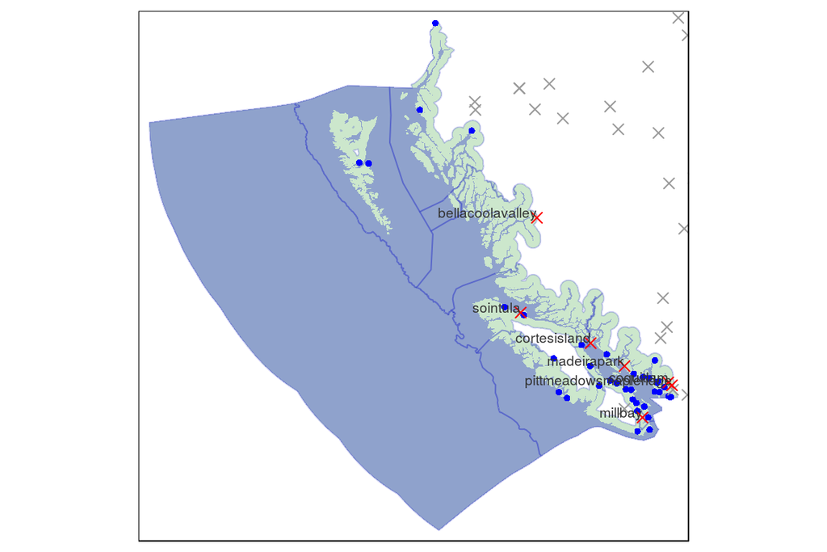

```r
vc_rgn_sum <- read_csv(file.path(dir_goal, 'int/vc_rgn_totals.csv')) %>%
  group_by(filename, vc_name, id) %>%
  summarize(tot_vis = sum(total, na.rm = TRUE)) %>%
  mutate(tot_vis = ifelse(is.na(filename), NA, tot_vis)) %>%
  filter(!is.na(vc_name))

vc_rgn_incl <- read_csv(file.path(dir_goal, 'int/vc_rgn_totals.csv')) %>%
  select(-year, -total) %>%
  filter(!is.na(rgn_id)) %>%
  distinct()


vc_pts_sf <- read_sf(dsn = file.path(dir_data_bc, 'tr/TourismCentres/HelloBC_visitor_centers/HLLBC_VC'),
                  layer = 'HLLBC_VC_point')

vc_pts_sf <- vc_pts_sf %>%
  setNames(tolower(names(.))) %>%
  select(id = product_id, tourregion, name) %>%
  mutate(id = as.integer(id)) %>%
  left_join(vc_rgn_sum, by = 'id') %>%
  mutate(vc_name = ifelse(is.na(vc_name),
                          str_replace_all(tolower(name), tolower(rgns_extra_text), '') %>%
                            str_replace_all('[^a-z]', ''),
                          vc_name))

bc_inland_rgns <- read_sf(dsn = dirname(bc_rgns_layer),
                          layer = basename(bc_rgns_layer))
bc_ocean_rgns <- read_sf(dsn = dir_spatial,
                          layer = 'ohibc_rgn_simple')


vc_map <- tm_shape(bc_inland_rgns) +
    tm_polygons(col = 'green4', border.col = 'blue3', alpha = .2, border.alpha = .2) +
  tm_shape(bc_ocean_rgns) +
    tm_fill(col = 'blue3', alpha = .3) +
  tm_shape(vc_pts_sf %>% filter(!is.na(tot_vis))) +
    tm_dots(col = 'blue', size = .1) +
  tm_shape(x <- vc_pts_sf %>% filter(is.na(tot_vis) & !id %in% vc_rgn_incl$id)) +
    tm_dots(col = 'grey60', shape = 4, size = .25) +
  tm_shape(y <- vc_pts_sf %>% filter(is.na(tot_vis) &  id %in% vc_rgn_incl$id)) +
    tm_dots(col = 'red', shape = 4, size = .25) +
    tm_text(text = 'vc_name',
            size = .6, just = c('right', 'bottom'),
            col = 'grey20') # +
  # tm_shape(vc_pts_sf %>% filter(vc_name %in% vc_no_spatial$vc_name)) +
  #   tm_text(text = 'vc_name',
  #           size = .6, just = c('right', 'bottom'),
  #           col = 'grey70')


print(vc_map)
```

```r
vc_no_logs <- vc_pts_sf %>%
  filter(is.na(tot_vis) & id %in% vc_rgn_incl$id) %>%
  as.data.frame() %>%
  select(name, tourregion)
```

Visitor centers mapped against OHIBC regions, using a 15 km inland buffer to define areas of “coastal” interest. Centers with logs are noted in blue; centers not included in OHIBC regions are noted as a grey X. Centers without logs, but within the boundaries of the inland regions, are named and marked with a red X, though these are generally visitor booths rather than full visitor centers.

|  | name | tourregion |
| --- | --- | --- |
| 1 | Bella Coola Valley Tourist/Visitor Info Booth | Cariboo Chilcotin Coast |
| 2 | Coquitlam Tourist/Visitor Info Booth | Vancouver Coast and Mountains |
| 3 | Cortes Island Tourist/Visitor Info Booth | Vancouver Island |
| 4 | Madeira Park Tourist/Visitor Info Booth | Vancouver Coast and Mountains |
| 5 | Mill Bay Tourist/Visitor Info Booth | Vancouver Island |
| 6 | Pitt Meadows/Maple Ridge Visitor Centre | Vancouver Coast and Mountains |
| 7 | Sointula Tourist/Visitor Info Booth | Vancouver Island |

#### 3.1.4.1 Number of visitor centers per region

(only centers with non-NA counts across all years)

```r
knitr::kable(vc_rgn_totals %>%
               filter(!is.na(total) & !is.na(rgn_id)) %>%
               select(rgn_id, name) %>%
               distinct() %>%
               group_by(rgn_id) %>%
               summarize(n_vis_ctrs = n()) %>%
               full_join(get_rgn_names(), by = 'rgn_id') %>%
               filter(rgn_id %in% c(1:6, 8)) %>%
               arrange(rgn_id))
```

| rgn_id | n_vis_ctrs | rgn_name | rgn_code |
| --- | --- | --- | --- |
| 1 | 3 | North Coast | NC |
| 2 | 2 | Haida Gwaii | HG |
| 3 | NA | Central Coast | CC |
| 4 | 3 | North Vancouver Island | NV |
| 5 | 6 | West Vancouver Island | WV |
| 6 | 23 | Strait of Georgia | SG |
| 8 | NA | Aristazabal Island | AZ |

## 3.2 Spatialize parks to OHIBC regions.

For parks that fall entirely within a region, the entire visitation count will be allocated to that region. For parks that cross between two regions, park visitation will be allocated based on proportion of total park area falling within each region.

### 3.2.1 Spatialize parks

Parks will be allocated by area within OHIBC regions.

- Get the Parks shapefile; create a column with total area of each park.
- get the OHIBC regions shapefile
  - unclipped version, with inland watersheds?
  - 15 km inland buffer (about 10 miles)? This is what we will go with.
- Intersect the parks and OHIBC regions to locate parks. Park “allocation” will be the ratio of area in OHIBC coastal region to total area (including area outside OHIBC coastal region), to allocate the visitors proportionally to each OHIBC region.
- Discard the spatial information and save as a CSV of parks <-> OHIBC regions.

```r
park_poly_sf <- read_sf(dsn = file.path(dir_data_bc, 'tr/ParkVisitation/ParkLocations/TA_PEP_SVW'),
                  layer = 'TA_PEP_SVW_polygon')

# glimpse(park_poly_sf %>% select(-geometry))

park_poly <- park_poly_sf %>%
  setNames(tolower(names(.))) %>%
  select(# id = objectid,
         name = prot_name,
         desig = prot_desg, code = prot_code, class = park_class) %>%
  mutate(tot_area = st_area(.))


bc_rgns_layer <- file.path(dir_goal, 'spatial', 'ohibc_clipped_15km_inland')
bc_rgns <- read_sf(dsn = dirname(bc_rgns_layer),
                   layer = basename(bc_rgns_layer)) %>%
  st_transform(st_crs(park_poly))

park_to_bc_sf <- st_intersection(park_poly, bc_rgns)

park_to_bc <- park_to_bc_sf %>%
  mutate(rgn_area = st_area(.)) %>%
  as.data.frame() %>%
  select(-geometry) %>%
  distinct()

write_csv(park_to_bc, file.path(dir_goal, 'int/park_locations.csv'))

# DT::datatable(park_to_bc, caption = 'Visitors centers within OHIBC regions')
```

### 3.2.2 Collate parks visitation logs

Read and parse parks logs.

- Read in all `.xls` files
  - NOTE: `readxl::read_excel` didn’t recognize the files as Excel files. Converted all to `.csv` and used `read_csv` instead.
- Parse down to just the Total Visitors per center per year, and save as .csv.

```r
dir_parks <- file.path(dir_data_bc, 'tr/ParkVisitation')

park_logs <- list.files(dir_parks, pattern = '.csv$', full.names = TRUE)

park_df_raw <- lapply(park_logs, FUN = function(x) read_csv(x)) %>%
  setNames(basename(park_logs)) %>%
  bind_rows(.id = 'filename') %>%
  setNames(tolower(names(.)))

### Decide: does a '-' count as zero or NA?  Assume NA; a park with zero
###   attendance is not much of a park...
park_df <- park_df_raw %>%
  mutate(rept_yr = str_extract(filename, '[0-9]{2}_[0-9]{2}'),
         year = str_replace(rept_yr, '[0-9]{2}_', ''),
         year = as.integer(year) + 2000,
         visits = as.integer(str_replace(count, '[^0-9]', ''))) %>%
  filter(!is.na(park)) %>%  ### NA park names: these are totals; exclude 'em
  select(park, visits, year) %>%
  distinct()


write_csv(park_df, file.path(dir_goal, 'int/park_totals.csv'))

# DT::datatable(park_df_total, caption = 'parks total visitors')
```

### 3.2.3 Attach parks logs to spatial parks

The visitor log filenames contain a reference to the park name; however, not an exact match to those in the spatial file.

- Parse the spatial file name down to the base center name, all lower case with no spaces.
- Do the same for the parks logs.
- Identify the spatial names that at least partially match the parks logs to create a lookup. The spatial names are more complete than the parks log file names.
- Link the spatial info to the visitor log info and save as .csv.

```r
### For spatial info, collapse name to just the base name, lower case, no spaces
park_rgns <- read_csv(file.path(dir_goal, 'int/park_locations.csv')) %>%
  mutate(park_name = str_replace_all(tolower(name), '[^a-z]', ''))

park_logs <- read_csv(file.path(dir_goal, 'int/park_totals.csv')) %>%
  mutate(log_name = str_replace_all(tolower(park), '[^a-z]', ''))

park_lookup <- lapply(park_rgns$park_name %>% unique(), FUN = function(x) {
  # x <- park_logs$log_name[1]
  name_match <- park_logs$log_name[str_detect(park_logs$log_name, x) | str_detect(x, park_logs$log_name) ]
  if (length(name_match) == 0) name_match <- NA
  y <- data.frame(park_name = x,
                  log_name  = name_match)
}) %>%
  bind_rows() %>%
  # mutate(full_match = (log_name == park_name)) %>%
  filter(log_name != 'lakepark')

### Lookup includes parks that fall spatially within OHIBC regions AND have
### visitation logs.  Some to note:
### Lake Park (inland somewhere? but falsely name-matches any 'XXX Lake Park')
### Sechelt Inlets Marine Park has numerous sites by spatial file.

park_rgn_totals_all <- park_logs %>%
  full_join(park_lookup, by = 'log_name') %>%
  full_join(park_rgns, by = 'park_name') %>%
  select(park, year, visits, park_name, rgn_area, tot_area, rgn_id) %>%
  distinct()

park_bc_totals <- park_rgn_totals_all %>%
  group_by(year) %>%
  summarize(bc_visits = sum(visits, na.rm = TRUE)) %>%
  ungroup()

park_rgn_totals <- park_rgn_totals_all %>%
  filter(!is.na(park_name) & !is.na(visits))


write_csv(park_rgn_totals, file.path(dir_goal, 'int/park_rgn_totals.csv'))
write_csv(park_bc_totals, file.path(dir_goal, 'int/park_totals_all_bc.csv'))

DT::datatable(park_rgn_totals %>%
                select(-park_name) %>%
                mutate(rgn_area = round(rgn_area),
                       tot_area = round(tot_area)))
```

|  | park | year | visits | rgn_area | tot_area | rgn_id |
| --- | --- | --- | --- | --- | --- | --- |
| 1 | Alice Lake Park | 2009 | 293226 | 4117249 | 4117249 | 6 |
| 2 | Bamberton Park | 2009 | 87787 | 266587 | 266587 | 6 |
| 3 | Bellhouse Park | 2009 | 2468 | 31054 | 31054 | 6 |
| 4 | Bodega Ridge Park | 2009 | 1558 | 3967202 | 3967202 | 6 |
| 5 | Burgoyne Bay Park | 2009 | 5835 | 5012462 | 5012462 | 6 |
| 6 | Cape Scott Park | 2009 | 10102 | 223096247 | 223096247 | 4 |
| 7 | Carmanah Walbran Park | 2009 | 1798 | 153353240 | 163644831 | 5 |
| 8 | Cowichan River Park | 2009 | 69479 | 2381283 | 14045235 | 6 |
| 9 | Desolation Sound Marine Park | 2009 | 15008 | 81397917 | 81397917 | 6 |
| 10 | Diana Lake Park | 2009 | 13447 | 2523627 | 2523627 | 1 |

[output cut: 462 more lines]

### 3.2.4 Map parks against OHIBC regions

```r
bc_rgns_layer <- file.path(dir_goal, 'spatial', 'ohibc_clipped_15km_inland')
bc_rgns <- read_sf(dsn = dirname(bc_rgns_layer),
                   layer = basename(bc_rgns_layer))
bc_ocean_rgns <- read_sf(dsn = dir_spatial,
                          layer = 'ohibc_rgn_simple')

park_rgn_sum <- read_csv(file.path(dir_goal, 'int/park_rgn_totals.csv')) %>%
  group_by(park_name, rgn_id) %>%
  filter(!is.na(visits)) %>%
  summarize(tot_vis = sum(visits, na.rm = TRUE)) %>%
  ungroup() %>%
  distinct()

# park_rgn_sum$rgn_id %>% table()

park_poly_sf <- read_sf(dsn = file.path(dir_data_bc, 'tr/ParkVisitation/ParkLocations/TA_PEP_SVW'),
                  layer = 'TA_PEP_SVW_polygon') %>%
  select(name = PROT_NAME) %>%
  mutate(name = tolower(name) %>% str_replace_all('[^a-z]', '')) %>%
  st_zm()

park_poly_incl <- park_poly_sf %>%
  st_intersection(bc_rgns %>%
                    st_transform(st_crs(park_poly_sf))) %>%
  filter(name %in% park_rgn_sum$park_name) %>%
  distinct()


park_map <- tm_shape(bc_rgns) +
    tm_polygons(col = 'green4', border.col = 'blue3', alpha = .2, border.alpha = .2) +
  tm_shape(bc_ocean_rgns) +
    tm_fill(col = 'blue3', alpha = .3) +
  tm_shape(park_poly_sf %>% filter(name %in% park_poly_incl$name)) +
    tm_polygons(col = 'grey60', border.col = 'grey30', lwd = .25, alpha = .3) +
  tm_shape(park_poly_incl) +
    tm_polygons(col = 'blue', alpha = .3, border.col = 'blue', lwd = .25, border.alpha = 1) +
  tm_shape(park_poly_sf %>% filter(!name %in% park_poly_incl$name)) +
    tm_fill(col = 'red', alpha = .3)

print(park_map)
```

[output not shown]

#### 3.2.4.1 Number of parks per region

(only parks with non-NA counts across all years)

```r
knitr::kable(park_rgn_totals %>%
               select(rgn_id, park) %>%
               distinct() %>%
               group_by(rgn_id) %>%
               summarize(n_parks = n()) %>%
               full_join(get_rgn_names(), by = 'rgn_id') %>%
               filter(rgn_id %in% c(1:6, 8)) %>%
               arrange(rgn_id))
```

| rgn_id | n_parks | rgn_name | rgn_code |
| --- | --- | --- | --- |
| 1 | 6 | North Coast | NC |
| 2 | 2 | Haida Gwaii | HG |
| 3 | NA | Central Coast | CC |
| 4 | 5 | North Vancouver Island | NV |
| 5 | 12 | West Vancouver Island | WV |
| 6 | 69 | Strait of Georgia | SG |
| 8 | NA | Aristazabal Island | AZ |

## 3.3 Create Output Layers

This script writes four layers for calculation of OHIBC Tourism and Recreation scores:

- Visitation to visitors centers/tourism centers, by year, by center, and by region. If we wish to count no net loss per center, rather than across the entire region, the center-by-center reports are necessary.
- Visitation to provincial parks, by year, by park, and by region. Again, center-by-center numbers are necessary in case we count no net loss on a park-by-park basis. In this step, visitations will be area-weighted by region area compared to total area, and count will report the resulting proportion of visitors.
- Overall visitation to visitors centers across all BC. This can be used to account for system-wide peaks and dips in park visitorship, such as economic downturns.
- Overall visitation to parks across all BC.

```r
vc_visits <- read_csv(file.path(dir_goal, 'int/vc_rgn_totals.csv')) %>%
  select(rgn_id, year, visits = total, name) %>%
  filter(!is.na(rgn_id) & !is.na(visits)) %>%
  distinct()

park_visits <- read_csv(file.path(dir_goal, 'int/park_rgn_totals.csv')) %>%
  filter(!is.na(rgn_id)) %>% ### filter to just OHIBC parks
  filter(!is.na(visits)) %>%
  mutate(visits_wt = round(visits * rgn_area / tot_area)) %>%
  select(rgn_id, year, visits_wt, name = park) %>%
  distinct()

vc_visits_all <- read_csv(file.path(dir_goal, 'int/vis_ctr_totals_all_bc.csv')) %>%
  select(year, visits = total)

park_visits_all <- read_csv(file.path(dir_goal, 'int/park_totals_all_bc.csv')) %>%
  filter(!is.na(year)) %>%
  rename(visits = bc_visits)

write_csv(vc_visits,       file.path(dir_goal, 'output/vis_ctr_visits.csv'))
write_csv(park_visits,     file.path(dir_goal, 'output/park_visits.csv'))
write_csv(vc_visits_all,   file.path(dir_goal, 'output/vis_ctr_visits_all.csv'))
write_csv(park_visits_all, file.path(dir_goal, 'output/park_visits_all.csv'))
```

## 3.4 Visualize

### 3.4.1 Visits normalized by max visits

Plotting the normalized visitation count (relative to the max count seen in the region) across all regions, and then the region-by-region count normalized by the proportional total province-wide count.

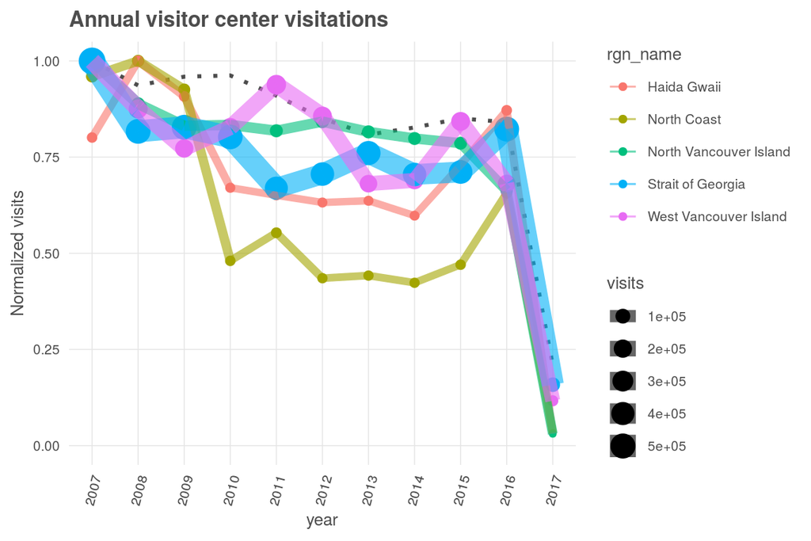

```r
vc_visits <- read_csv(file.path(dir_goal, 'output/vis_ctr_visits.csv')) %>%
  group_by(rgn_id, year) %>%
  summarize(visits = sum(visits)) %>%
  group_by(rgn_id) %>%
  mutate(visits_norm = visits / max(visits)) %>%
  left_join(get_rgn_names(), by = 'rgn_id') %>%
  ungroup()
vc_visits_all <- read_csv(file.path(dir_goal, 'output/vis_ctr_visits_all.csv')) %>%
  mutate(rgn_name = 'All province',
         visits_norm = visits / max(visits))


vc_plot <- ggplot(vc_visits, aes(x = year, y = visits_norm, size = visits, color = rgn_name)) +
  ggtheme_plot() +
  geom_line(data = vc_visits_all,
            size = 1, color = 'grey30', linetype = 'dotted') +
  geom_point() +
  geom_line(aes(group = rgn_name, size = visits), alpha = .6) +
  scale_x_continuous(breaks = c(2005:2017)) +
  theme(axis.text.x = element_text(angle = 75, hjust = 1)) +
  scale_y_continuous(limits = c(0, NA)) +
  labs(title = 'Annual visitor center visitations',
       y     = 'Normalized visits',
       fill  = 'OHIBC region')
print(vc_plot)
```

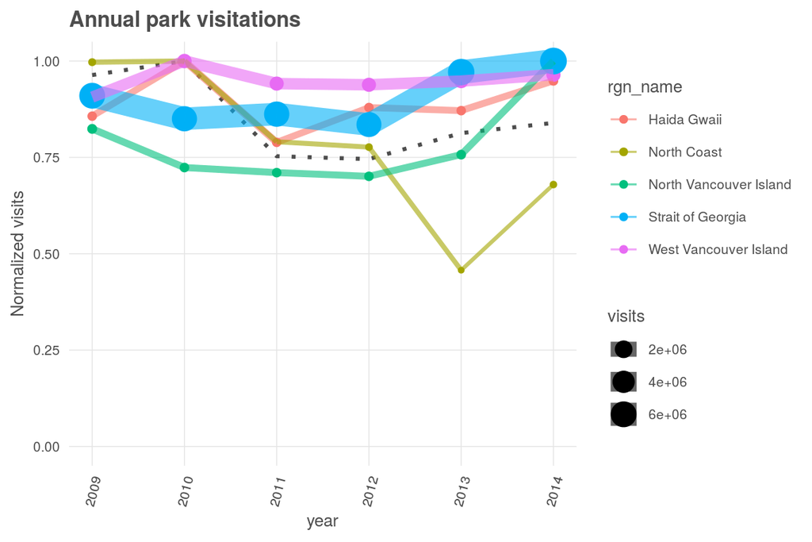

```r
park_visits <- read_csv(file.path(dir_goal, 'output/park_visits.csv')) %>%
  group_by(rgn_id, year) %>%
  summarize(visits = sum(visits_wt)) %>%
  group_by(rgn_id) %>%
  mutate(visits_norm = visits / max(visits)) %>%
  left_join(get_rgn_names(), by = 'rgn_id') %>%
  ungroup()
park_visits_all <- read_csv(file.path(dir_goal, 'output/park_visits_all.csv')) %>%
  mutate(rgn_name = 'All province',
         visits_norm = visits / max(visits))

parks_plot <- ggplot(park_visits, aes(x = year, y = visits_norm, size = visits, color = rgn_name)) +
  ggtheme_plot() +
  geom_line(data = park_visits_all,
            size = 1, color = 'grey30', linetype = 'dotted') +
  geom_point() +
  geom_line(aes(group = rgn_name), alpha = .6) +
  scale_x_continuous(breaks = c(2005:2017)) +
  theme(axis.text.x = element_text(angle = 75, hjust = 1)) +
  scale_y_continuous(limits = c(0, NA)) +
  labs(title = 'Annual park visitations',
       y     = 'Normalized visits',
       fill  = 'OHIBC region')

print(parks_plot)
```

### 3.4.2 Visits adjusted by province-wide tourism

Plotting the normalized visitation count adjusted by the normalized total count across the province, to eliminate systemic factors that affect tourism province-wide.

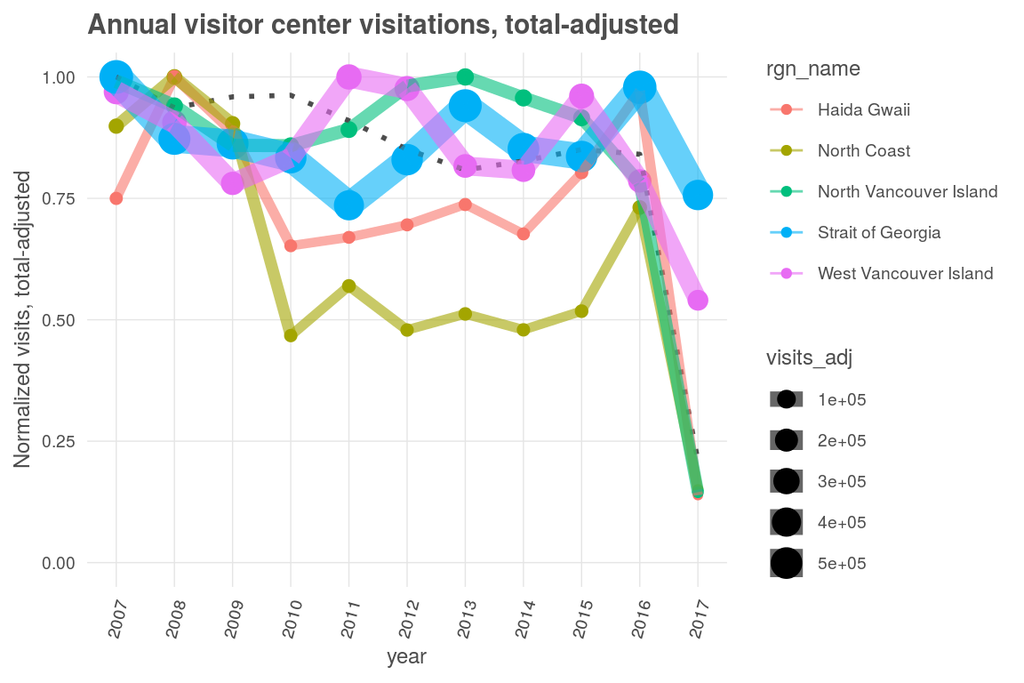

```r
vc_visits_adj <- vc_visits %>%
  left_join(vc_visits_all %>%
              select(visits_all = visits, year),
            by = 'year') %>%
  mutate(visits_all_norm = visits_all / max(visits_all)) %>%
  group_by(rgn_id) %>%
  mutate(visits_adj = visits / visits_all_norm,
         visits_norm_adj = visits_adj / max(visits_adj)) %>%
  ungroup()


vc_plot <- ggplot(vc_visits_adj, aes(x = year, y = visits_norm_adj, size = visits_adj, color = rgn_name)) +
  ggtheme_plot() +
  geom_point() +
  geom_line(aes(y = visits_all_norm), size = 1, color = 'grey30', linetype = 'dotted') +
  geom_line(aes(group = rgn_name, size = visits), alpha = .6) +
  scale_x_continuous(breaks = c(2005:2017)) +
  theme(axis.text.x = element_text(angle = 75, hjust = 1)) +
  scale_y_continuous(limits = c(0, NA)) +
  labs(title = 'Annual visitor center visitations, total-adjusted',
       y     = 'Normalized visits, total-adjusted',
       fill  = 'OHIBC region')
print(vc_plot)
```

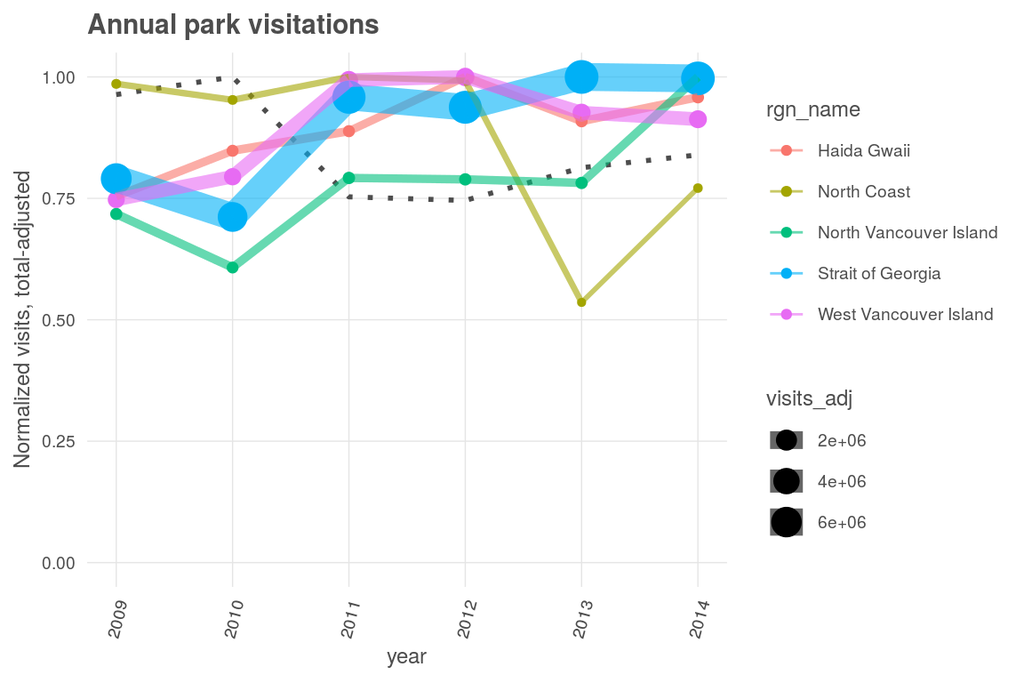

```r
park_visits_adj <- park_visits %>%
  left_join(park_visits_all %>%
              select(visits_all = visits, year),
            by = 'year') %>%
  mutate(visits_all_norm = visits_all / max(visits_all)) %>%
  group_by(rgn_id) %>%
  mutate(visits_adj = visits / visits_all_norm,
         visits_norm_adj = visits_adj / max(visits_adj)) %>%
  ungroup()

park_plot <- ggplot(park_visits_adj, aes(x = year, y = visits_norm_adj, size = visits_adj, color = rgn_name)) +
  ggtheme_plot() +
  geom_point() +
  geom_line(aes(y = visits_all_norm), size = 1, color = 'grey30', linetype = 'dotted') +
  geom_line(aes(group = rgn_name, size = visits), alpha = .6) +
  scale_x_continuous(breaks = c(2005:2017)) +
  theme(axis.text.x = element_text(angle = 75, hjust = 1)) +
  scale_y_continuous(limits = c(0, NA)) +
  labs(title = 'Annual park visitations',
       y     = 'Normalized visits, total-adjusted',
       fill  = 'OHIBC region')
print(park_plot)
```

```r
prov_wrapup()
```

# 4 Provenance

- *Run ID: 12 (3adf55d); run tag: “standard run”*
- *Run elapsed time: 45.771 seconds; run memory usage: 3269.6 MB*
- *System info:*
  - *System: Linux, Release: 4.4.0-133-generic. Machine: x86_64. User: ohara.*
  - *R version: R version 3.4.4 (2018-03-15), Platform: x86_64-pc-linux-gnu, Running under: Ubuntu 14.04.5 LTS.*
  - *Attached base packages: stats, graphics, grDevices, utils, datasets, methods, base*
  - *Other attached packages: bindrcpp_0.2.2, provRmd_0.1.1, RColorBrewer_1.1-2, forcats_0.3.0, stringr_1.3.1, dplyr_0.7.6, purrr_0.2.5, readr_1.1.1, tidyr_0.8.1, tibble_1.4.2, ggplot2_3.0.0, tidyverse_1.2.1, tmap_2.0, sf_0.6-3, raster_2.6-7, sp_1.3-1*

[figure not shown]

| sequence | file_name | parent_chunk | file_dir | filetype | uncomm_chgs | commit_hash_short |
| --- | --- | --- | --- | --- | --- | --- |
| 0 | data_prep_tr.Rmd | provenance | ~/github/ohibc/prep/tr/v2017 | parent_script | True | 95d1fa9 |
| 0 | data_prep_tr.Rmd#attach_park_logs_and_spatial | attach_park_logs_and_spatial | ~/github/ohibc/prep/tr/v2017 | parent_chunk | True | 95d1fa9 |
| 0 | data_prep_tr.Rmd#attach_vc_logs_and_spatial | attach_vc_logs_and_spatial | ~/github/ohibc/prep/tr/v2017 | parent_chunk | True | 95d1fa9 |
| 0 | data_prep_tr.Rmd#collate_park_logs | collate_park_logs | ~/github/ohibc/prep/tr/v2017 | parent_chunk | True | 95d1fa9 |
| 0 | data_prep_tr.Rmd#collate_vis_ctr_logs | collate_vis_ctr_logs | ~/github/ohibc/prep/tr/v2017 | parent_chunk | True | 95d1fa9 |
| 0 | data_prep_tr.Rmd#data_viz_normalized_visits | data_viz_normalized_visits | ~/github/ohibc/prep/tr/v2017 | parent_chunk | True | 95d1fa9 |
| 0 | data_prep_tr.Rmd#map_vis_ctrs | map_vis_ctrs | ~/github/ohibc/prep/tr/v2017 | parent_chunk | True | 95d1fa9 |
| 0 | data_prep_tr.Rmd#provenance | provenance | ~/github/ohibc/prep/tr/v2017 | parent_chunk | True | 95d1fa9 |
| 0 | data_prep_tr.Rmd#spatialize_parks | spatialize_parks | ~/github/ohibc/prep/tr/v2017 | parent_chunk | True | 95d1fa9 |
| 0 | data_prep_tr.Rmd#spatialize_visitor_centers | spatialize_visitor_centers | ~/github/ohibc/prep/tr/v2017 | parent_chunk | True | 95d1fa9 |

[output cut: 75 more lines]